# NEON data tables and graphs

## Libraries

```r
library(tidyverse)
library(knitr)
library(DT)
```

## Wrangling summary file

Our data that we will work with today can be found by searching metagenome bins associated with GOLD Study ID Gs0161344 [IMG/MER](https://img.jgi.doe.gov/cgi-bin/mer/main.cgi?section=MetagenomeBinSearch&page=searchForm)

A description of the column headers for the file we will work with

- Bin ID - Metagenome Assemble Genome (MAG) ID
- Genome Name - The metagenome sample name
- IMG Genome ID - The metagenome sample ID
- Bin Quality - An estimate of the quality of the bin or MAG
- Bin Lineage - Taxonomic lineage using the JGI system
- GTDB-Tk Taxonomy Lineage - Taxonomic lineage using GTDB
- Bin Methods - The methods for binning contigs and quality control
- Created By - The process by which the bins were created
- Date Added - Date sample/metagenome was added
- Bin Completeness - An estimate of the completeness of the MAG
- Bin Contamination - An estimate of the contamination of the MAG
- Total Number of Bases - MAG size in bases
- 5s rRNA - Count of 5s rRNAs in the MAG
- 16s rRNA - Count of 16S rRNAs in the MAG
- 23s rRNA - Count of 23s rRNAs in the MAG
- tRNA Genes - Count of tRNA genes in the MAG
- Gene Count - Count of number of genes in the MAG
- Scaffold Count - Number of separate scaffold comprising the MAG. The ideal would be 1
- GOLD Study ID - The ID in the JGI GOLD database

Let’s load the table into R

```r
NEON_MAGs <- read_csv("data/NEON/GOLD_Study_ID_Gs0161344_NEON.csv") %>%
  # remove columns that are not needed for data analysis
  select(-c(`GOLD Study ID`, `Bin Methods`, `Created By`, `Date Added`)) %>%
  # create a new column with the Assembly Type
  mutate("Assembly Type" = case_when(`Genome Name` == "NEON combined assembly" ~ `Genome Name`,
                            TRUE ~ "Individual")) %>%
  mutate_at("Assembly Type", str_replace, "NEON combined assembly", "Combined") %>%
  separate(`GTDB-Tk Taxonomy Lineage`, c("Domain", "Phylum", "Class", "Order", "Family", "Genus"), "; ", remove = FALSE) %>%
  # Get rid of the the common string "Soil microbial communities from "
  mutate_at("Genome Name", str_replace, "Terrestrial soil microbial communities from ", "") %>%
  # Use the first `-` to split the column in two
  separate(`Genome Name`, c("Site","Sample Name"), " - ") %>%
  # Get rid of the the common string "S-comp-1"
  mutate_at("Sample Name", str_replace, "-comp-1", "") %>%
  # separate the Sample Name into Site ID and plot info
  separate(`Sample Name`, c("Site ID","subplot.layer.date"), "_", remove = FALSE,) %>%
  # separate the plot info into 3 columns
  separate(`subplot.layer.date`, c("Subplot", "Layer", "Date"), "-")
NEON_MAGs_bact <- NEON_MAGs %>%
  # remove Archaea since there is no GTDB annotation for Archaea
  filter(Domain == "Bacteria")
```

## Tables

### Assembly type by Bin Qualit

```r
  NEON_MAGs_bact %>%
   group_by(`Assembly Type`, `Bin Quality`) %>%
   count(`Bin Quality`)
```

```
## # A tibble: 4 × 3
## # Groups:   Assembly Type, Bin Quality [4]
##   `Assembly Type` `Bin Quality`     n
##   <chr>           <chr>         <int>
## 1 Combined        HQ               30
## 2 Combined        MQ              588
## 3 Individual      HQ               96
## 4 Individual      MQ              996
```

### Assemby Type by Phylum Count

```r
datatable(
  NEON_MAGs_bact %>%
   group_by(`Assembly Type`, Phylum) %>%
   summarize(n = n()) %>%
   pivot_wider(names_from = `Assembly Type`, values_from = n) %>%
   mutate(pct_change = (Combined-Individual)/(Individual) * 100) %>%
   mutate_if(is.numeric, round, 0)
)
```

|  | Phylum | Combined | Individual | pct_change |
| --- | --- | --- | --- | --- |
| 1 | Acidobacteriota | 125 | 181 | -31 |
| 2 | Actinobacteriota | 253 | 418 | -39 |
| 3 | Bacteroidota | 11 | 22 | -50 |
| 4 | Chlamydiota | 1 | 1 | 0 |
| 5 | Chloroflexota | 12 | 35 | -66 |
| 6 | Cyanobacteria | 1 | 2 | -50 |
| 7 | Desulfobacterota | 2 | 5 | -60 |
| 8 | Desulfobacterota_B | 4 | 9 | -56 |
| 9 | Dormibacterota | 11 | 11 | 0 |
| 10 | Eisenbacteria | 1 | 1 | 0 |

[output cut: 14 more lines]

```r
datatable(
  NEON_MAGs_bact %>%
   group_by(`Assembly Type`, Family) %>%
   summarize(n = n()) %>%
   pivot_wider(names_from = `Assembly Type`, values_from = n) %>%
   mutate(pct_change = (Combined-Individual)/(Individual) * 100) %>%
   mutate_if(is.numeric, round, 0)
)
```

|  | Family | Combined | Individual | pct_change |
| --- | --- | --- | --- | --- |
| 1 | 2-12-FULL-66-21 | 3 | 5 | -40 |
| 2 | 20CM-2-55-15 | 1 | 1 | 0 |
| 3 | 40CM-4-68-19 | 1 | 3 | -67 |
| 4 | 70-9 | 34 | 39 | -13 |
| 5 | AC-67 | 1 | 3 | -67 |
| 6 | Acetobacteraceae | 10 | 21 | -52 |
| 7 | Acidobacteriaceae | 10 | 16 | -38 |
| 8 | Acidothermaceae | 1 | 2 | -50 |
| 9 | Anaeromyxobacteraceae | 1 | 1 | 0 |
| 10 | BOG-932 | 1 | 2 | -50 |

[output cut: 165 more lines]

## Figures

### Assembly Type by Phylum Bar

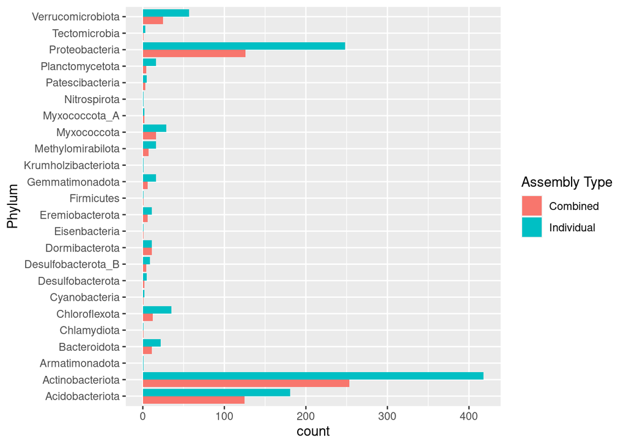

```r
NEON_MAGs_bact %>%
ggplot(aes(x = Phylum, fill = `Assembly Type`)) +
  geom_bar(position="dodge") +
  coord_flip()
```